# Coeficientes para la corrección de bias

La correcta asimilación de observaciones de satélite, en particular radianzas, depende en gran medida de la estimación y corrección del bias asociado a cada observación. Si el bias no es corregido podría afectar el análisis y los pronósticos generados generando impactos negativos.

Uno de los desafíos en la corrección de bias para asimilación regional es la cantidad de observaciones disponibles en cada ciclo de asimilación lo que depende a su vez de la ubicación y orbitas de los distintos satélites. En la región de Sudamérica los distintos satélites polares pasan una o dos veces por día y el dominio escaneado es variable. A esta restricción se suma la disminución de observaciones disponibles debido al límite superior de los modelos regionales.

El sistema GSI-LETKF incorpora un metodo de corrección de bias que estima y actualiza coeficientes $\beta_i$ que se aplican a una regresón lineal previo a la estimación del estado final o análisis (Miyoshi, Sato, and Kadowaki 2010). Esta estimación se calcula aplicando la ecuación:

$$\delta\beta = (B_{\beta}^{-1} + PR^{-1})^{-1}PR^{-1}[y-H(x)-P^{T}\beta]$$

Esta formulación es equivalente a la utilizada por la versión variacional de GSI y análoga a la ecuación del cálculo del análisis con la inclusión de la corrección de bias. En la ecuación $\delta\beta$ se asume diagonal y sus elementos se inicializan con el valor 0.1 y luego de su estimación que se calcula de manera iterativa, los coeficientes son actualizados:

$$\beta = \beta_b+\delta \beta$$

La corrección del bias se calcula utilizanod una regresión lineal con $N$ predictores independientes $P_i(x)$ y sus correspondientes coeficientes $\beta_i$.

$$BC = \sum_{i=1}^{N} \beta_i P_i(x)$$

La corrección del bias luego es aplicada directamente sobre la innovación $y - H(x)$.

Los predictores utilizados para la corrección asociada al estado de la atmósferea en este sistema corresponden a:

- Global offset
- Zenit angle
- Cloud liquid water (CLW)
- Temperature lapse rate (TLR)
- Temperature lapse rate al cuadrado

Mientras que la corrección asociada al ángulo de observación utiliza un polinomio de grado N.

El cálculo de CLW y TLR depende de cada sensor y se realiza como parte de las rutinas de GSI.

De acuerdo a Zhu et al. (2019) los coeficientes utilizados en la corrección del bias deben ser entrenados durante un periodo largo de tiempo y muestra que este tiempo es variable para cada canal de cada sensor. Con esto en mente se propone el siguiente experimento para el entrenamiento de los coeficientes.

### 0.0.1 Diseño experimental

Distintos trabajos abordan el entrenamiento de los coeficientes de corrección de bias en dominios regionales donde la cobertura de observaciones satélitales no es homogenea de manera similar. Por ejemplo Schwartz et al. (2012) utiliza un “spin up” de una semana para el entrenamiento de los coeficientes utilizando un método variacional con ciclos de asimilación cada 6 horas en un dominio regional mientras que Liu et al. (2012) utiliza un método “offline” durante 3 meses para obtener coeficientes de corrección estables. En particular Zhu et al. (2019) propone un periodo de entrenamiento de 9 días utilizando un método variacional determina que es necesario repetir este periodo una vez más para obtener coeficientes estables.

Para obtener coeficientes que permitan la correcta asimilación de observaciones de radianzas durante el periodo 18 UTC 20/11/2018 - 12 UTC 23/11/2018 se realizará asimilación continua entre las 18 UTC 11/11/2018 y las 12 UTC del 20/11/2018.

En este periodo de entrenamiento se observaron distintos fenómenos de tiempo severo asociados a sistemas convectivos de mesoescala y periodos de menor actividad por lo que se espera que la variedad de condiciones atmósfericas favorescan el entrenamiento de coeficientes pese al corto periodo de tiempo (9 días). Para garantizar esto y siguiendo a Zhu et al. (2019) este entrenamiento se realizará dos veces. Para el primer ciclo de asimilación se utilizaron los coeficientes de corrección de bias utilizados por GFS para la misma hora con la intención de acelerar el entramiento en comparación con una inicialización desde “0”. Al finalizar el primer período de asimilación (experimento pre-RAD1) los coeficientes resultantes del último ciclo son utilizados al comenzar el segundo periodo de asimilación en las mismas fechas (pre-RAD2).

El experimento de asimilación se realizará en el dominio que se muestra en la Figura 1 realizando ciclos contínuos a cada hora. El dominio tiene una reticula horizontal de 10 km y el tope del modelo en 50 hPa. En cada ciclo se incluyen las observaciones disponibles en la ventana de asimilación de 1 hora centrada en la hora del análisis incluyendo observaciones convencionales en el prepBUFR, observaciones de estaciones automáticas en el dominio, vientos derivados de satélite y radianzas de sensores en satélites polares listados en la Tabla 1.

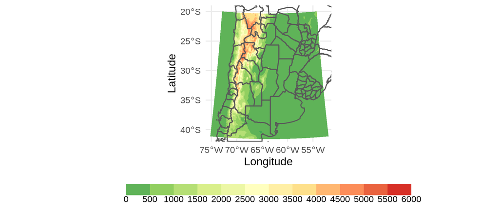

Figure 1: Dominio horizontal del modelo

Table 1: Lista de sensores con la cantidad de canales aceptados por GSI

| Sensor | Plataforma | N° de canales asimilables |
| --- | --- | --- |
| airs | aqua | 118 |
| amsua | n15 | 13 |
|  | n18 | 13 |
|  | aqua | 7 |
|  | n19 | 13 |
|  | metop-b | 6 |
| atms | npp | 21 |
|  | n20 | 21 |
| cris-fsr | npp | 100 |
|  | n20 | 100 |
| hirs4 | metop-a | 14 |
|  | n19 | 14 |
| iasi | metop-a | 174 |
|  | metop-b | 174 |
| mhs | n18 | 5 |
|  | metop-a | 5 |
|  | n19 | 5 |
|  | metop-b | 5 |

#### 0.0.1.1 Radianzas

La información de radianzas provienen de los sensores AMSU-A, AIRS, MHS, AIRS, IASI, HIRS todos en satélites de orbita polar. Estas observaciones son parte del sistema de transferencia de datos que utiliza GFS disponibles cada 6 horas pero asimiladas en ciclos horarios utilizando las observaciones correspondientes a una ventana centrada en la hora del análisis.

Se utilizaron observaciones en aire claro (ver métodos para detectar nubles usado por GSI) y se aplicó un control de calidad específico para cada sensor a fin de rechazar observaciones erroneas. A si mismo para tener en cuenta la resolución de cada observación se aplicó un thining de 60 km. Este valor fue definido siguiendo la metodología de otros trabajos en el área (Zhu et al. (2016), Jones et al. (2020), Lin et al. (2017), and Singh et al. (2016)).

En la Figura 2 se muestra la cantidad de observaciones potencialmente asimilables, es decir, que pasan el control de calidad del operador de las observaciones, para cada canal en cada ciclo de asimilación. Dejando de lado IASI que no se ve nada porque tiene más de 600 canales, se puede ver que en todo los casos hay outliers. Esto tiene que ver con que en cada ciclo solo hay disponibles observaciones de algunos sensores y no siempre la pasada del sensor coincide completamente con el dominio. Los momenos donde la cantidad de observaciones aumenta considerablemente coinciden con los momentos donde la pasada del satélite estaba centrada en el dominio. En general hay más observaciones en el rango infrarrojo tanto por las observaciones de los sensores multiespectrales (AIRS e IASI) como por el sensor HIRS que en general para todos los canales aporta mayor cantidad de observaciones.

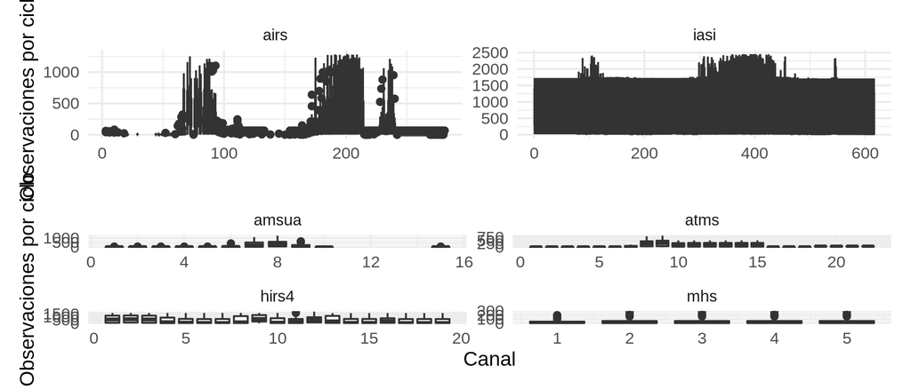

Figure 2: Cantidad de observaciones potencialmene asimilables en cada ciclo de asimilación para el experimento pre-RAD1

En cuanto a la altura de las observaciones (Figura 3), determinada a partir del máximo de la función de peso, muchas observaciones de canales de todos los sensores menos MHS correspoenden a alturas por encima del tope del modelo (50 hPa). Respecto de observaciones en el rango de microondas el sensor ATMS aporta la mayor cantidad de observaciones en niveles medios y altos y lo mismo ocurre con AMSU-A. En cuanto a las observaciones en el infrarrojo AIRS aporta muchas observaciones entre superficie y 200 hPa mientras que los canales de HIRS4 con observaciones en niveles medios y bajos muestran un comportamiento más variane y aporta en general menos observaciones.

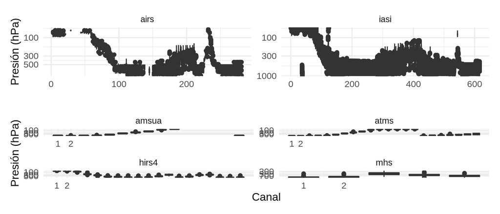

Figure 3: Nivel de presión asociado a las observaciones potencialmene asimilables en cada ciclo de asimilación para el experimento pre-RAD1

### 0.0.2 Evolución de los coeficientes de corrección.

El entrenamiento de los coeficientes varia sensor a sensor y canal a canal, de acuerdo a lo observado en la bibliografía el tiempo de entrenamiento necesario es variable en cada caso. Al mismo tiempo al ser asimilación regional y horaria podría afectar el tiempo que demora la estabilización de los coeficientes de corrección.

Por ejemplo en la Figura 4 se muestra la evolución de algunos de los coeficientes de canales del AMSU-A en NOAA15 en linea llena para la primera semana de entrenamiento pre-RAD1 y en línea punteada para la segunda semana pre-RAD2. Al igual que Zhu et al. (2019) se observa que cada coeficiente se estabiliza a una velocidad distinta, por ejemplo el coeficiente de emisividad en el canal 8 si bien hacia el final de la semana 2 muestra un comportamiento similar a la semana 1, los valores no son tan cercanos mientras que el TLR tiene un comportamiento muy similar en casi todo el periodo. Lamentablemente Zhu et al. (2019) no muestra otros canales (solo canal 5) pero es esperable que cada uno muestre variaciones.

En general algunos coeficientes para algunos canales no requieren casi entrenamiento mientras que a otros capaz les vendría bien una semanita más.

[link a gráficos de todos los sensores y canales](https://www.dropbox.com/sh/a64be0ognp0js0a/AAC6r8AXAGZ45dNFdvF1r8AEa?dl=0)

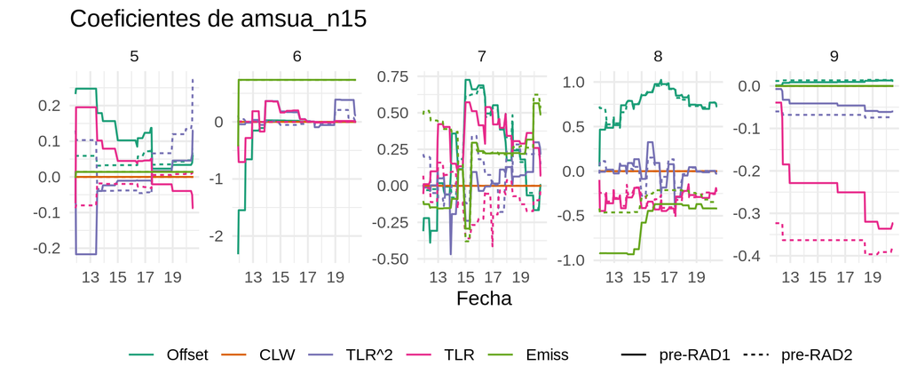

Figure 4: Coeficientes de corrección de bias en cada ciclo de asimilación para los canales 5 a 9 del sensor AMSU-A de NOAA-15.

Otro ejemplo se observa en la Figura 5 correspondiente a los coeficientes el sensor MHS a bordo del satelite METOP-A. En este caso por ejemplo para el canal 3 se observa como el Offset se mantuvo aprximadamente constante luego de 6 días de entrenamiento mientras que el TLR en el canal 5 continua variando aún luego de la segunda semana.

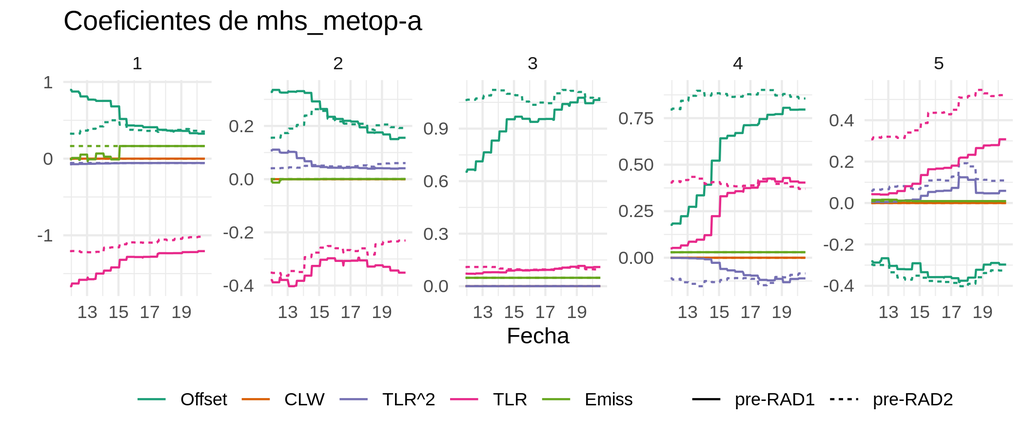

Figure 5: Coeficientes de corrección de bias en cada ciclo de asimilación para los canales del sensor MHS en METOP-A.

### 0.0.3 Corrección del bias

#### 0.0.3.1 AMSU-A

Si observamos la corrección de bias para cada canal de la familia de sensores AMSU-A se ven diferencias interesantes entre los dos periodos pre-RAD1 y pre-RAD2. Para analizar estas diferencias en la Figura 6 hay que tener en cuenta que no todas las observaciones cumplen las condiciones para ser asimiladas y por lo tanto el BIAS no es corregido o si es corregido los coeficientes no son actualizados en cada ciclo. En particular los canales 4 a 7 muestran una mejora en la mediana del bias (más cercana a cero) y/o en la dispersión (menor rango intercuartil y/o menos valores extremos).

La evolución de bias a lo largo del tiempo para el sensor sobre NOAA15 (Figura 7) muestra cambios entre los dos periodos en algunos casos del orden de 0.5 grados. En general el comportamiento del bias en el periodo pre-RAD2 mejora respecto del otro periodo y en los casos donde esto no ocurre as diferencias son muy pequeñas.

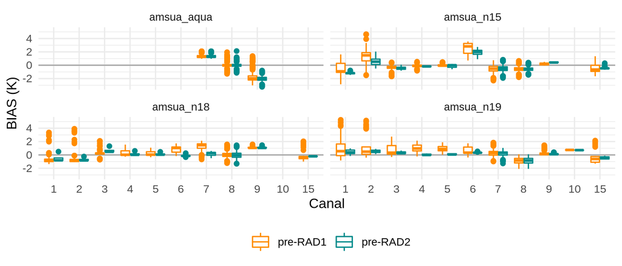

Figure 6: Bias de las radianzas de AMSU-A en las distintas plataformas y para los dos periodos.

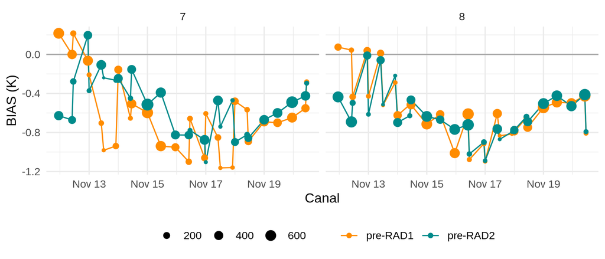

Analizando específicamente los resultados de los experimentos, se ve que la contribución de cada predictor es distinta para los canales mostrados y además es distinta entre sensores. Por ejemplo Para el canal 5 del AMSU-A NOAA19 el predictor asociado a emisividad es el que más contribuye mientras que para NOAA18 el TLR^2 tambien contribuye. Esto se ve también en canal 7 donde a veces contribuye más el TLR, otras veces el TLR^2.

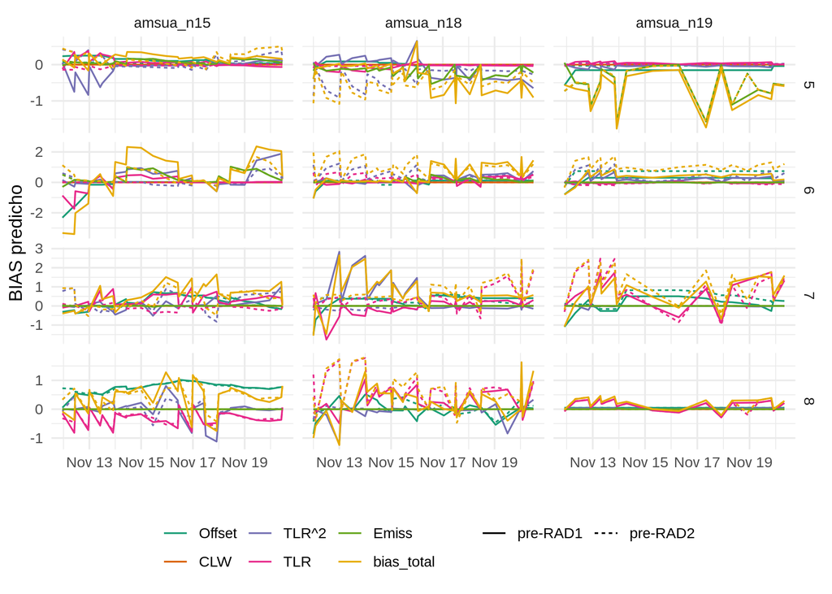

Figure 8: Evolución temporal del bias asociado a cada predictor para los sensores AMSU-A en las distintas plataformas

La distribución espacial de la corrección de bias aportada por distintos predictores para un tiempo particular se puede observar en la Figura 9. En este caso el TLR^2 muestra valores comparables con la literatura y en particular un máximo que ocupa gran parte del dominio. El predictor asociado a la emisividad presenta valores distinto de cero solo en la zona de topografía.

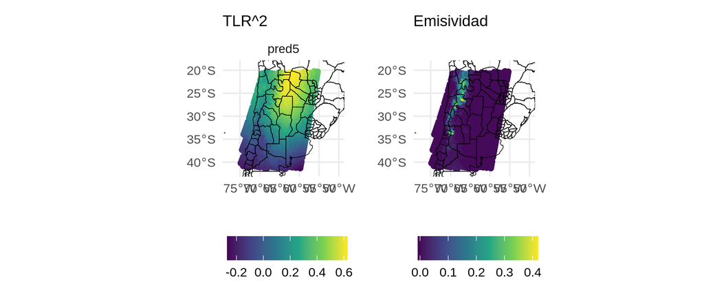

#### 0.0.3.2 MHS

La corrección del bias para el sensor MHS en cada periodo es menos clara que para AMSU-A (Figura 10). Los cambios en pre-RAD2 son mínimos y en algunos casos negativos. Por ejemplo el canal 1 que tiene el máximo cerca de superficie es el que muestra mayor dispersión, esto mejora mucho para el sensor sobre METOP-A y B (aunque en este ultimo caso la mediana se aleja de cero) pero para NOAA19 la dispersión no cambia particularmente (pero la mediana está más cerca de cero).

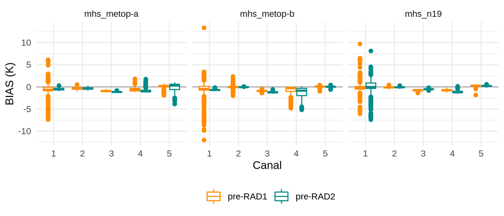

Figure 10: Bias de las radianzas de MHS en las distintas plataformas y para los dos periodos.

De la misma manera la evolución temporal del bias para este sensor es muy variable y el periodo pre-RAD2 no muestran mejoras marcadas (Figura 11. Los valores de bias aumentan y disminuyen alternativamente [TODO: podría deberse a la cantidad de observaciones? eso parece cumplirse en el canal 4 pero se ve lo contrario en el canal 2].

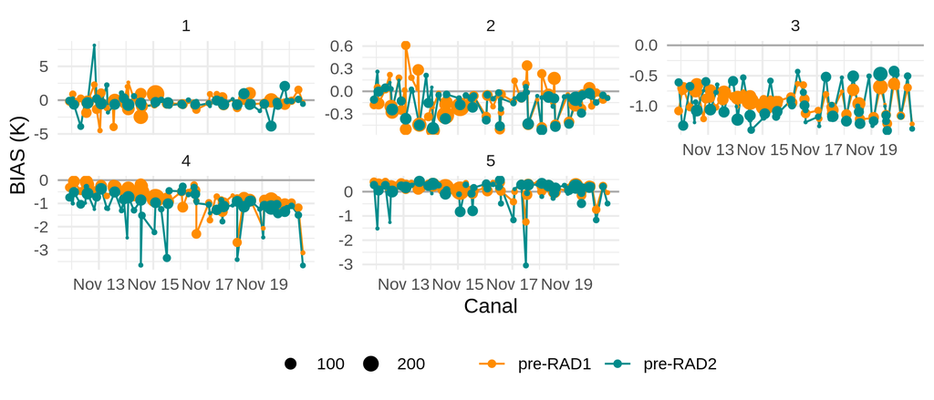

Figure 11: Bias medio de las radianzas de MHS para los dos periodos a lo largo del tiempo.

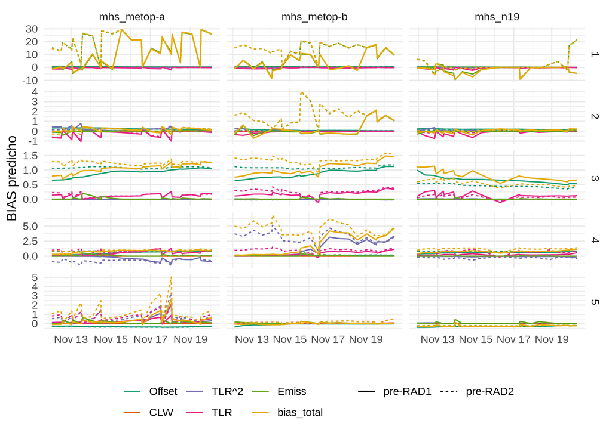

Figure 12: Evolución temporal del bias asociado a cada predictor para los sensores MSH en las distintas plataformas

La distribución espacial de la corrección del bias asociado a los predictores de TLR^2 y emisividad para un tiempo en particular se muestran en la Figura 13. En este tiempo la pasada del satélite cubrió gran parte del dominio. Respecto de la corrección asociada a la emisividad se observan valores distintos de cero en algunas regiones muy localizadas (sucede parecido en otros tiempos) en las zonas de mayor topografía. Esto podría deberse a que el nivel de presión asociado a esas observaciones se encuentra más cerca de la superficie? El TLR^2 tiene valores pequeños y varian de signo según la región.

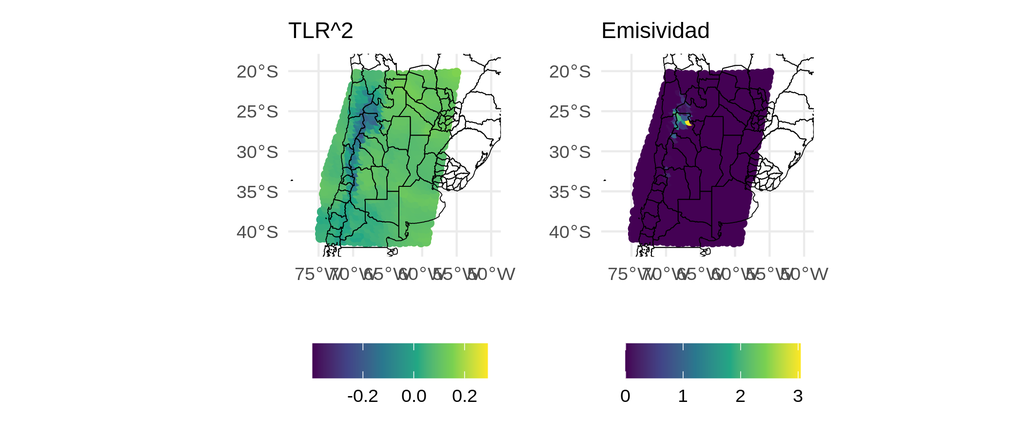

Figure 13: Contribución a la corrección del bias de dos predictores para el canal 3 de MHS NOAA19 a las 8 UTC del 17/11/2018

### 0.0.4 Colophon

The current Git commit details are:

```
#> Local:    main /home/paola.corrales/mesoda
#> Remote:   main @ origin (git@github.com:paocorrales/mesoda.git)
#> Head:     [f278eb6] 2020-10-15: Mañana intento de nuevo
```

Jones, Thomas A., Patrick Skinner, Nusrat Yussouf, Kent Knopfmeier, Anthony Reinhart, Xuguang Wang, Kristopher Bedka, William Smith, and Rabindra Palikonda. 2020. “Assimilation of GOES-16 Radiances and Retrievals into the Warn-on-Forecast System.” *Monthly Weather Review* 148 (5): 1829–59. https://doi.org/10.1175/MWR-D-19-0379.1.

Lin, Haidao, Stephen S. Weygandt, Agnes H. N. Lim, Ming Hu, John M. Brown, and Stanley G. Benjamin. 2017. “Radiance Preprocessing for Assimilation in the Hourly Updating Rapid Refresh Mesoscale Model: A Study Using AIRS Data.” *Weather and Forecasting* 32 (5): 1781–1800. https://doi.org/10.1175/WAF-D-17-0028.1.

Liu, Zhiquan, Craig S. Schwartz, Chris Snyder, and So-Young Ha. 2012. “Impact of Assimilating AMSU-A Radiances on Forecasts of 2008 Atlantic Tropical Cyclones Initialized with a Limited-Area Ensemble Kalman Filter.” *Monthly Weather Review* 140 (12): 4017–34. https://doi.org/10.1175/MWR-D-12-00083.1.

Miyoshi, Takemasa, Yoshiaki Sato, and Takashi Kadowaki. 2010. “Ensemble Kalman Filter and 4D-Var Intercomparison with the Japanese Operational Global Analysis and Prediction System.” *Monthly Weather Review* 138 (7): 2846–66. https://doi.org/10.1175/2010MWR3209.1.

Schwartz, Craig S., Zhiquan Liu, Yongsheng Chen, and Xiang-Yu Huang. 2012. “Impact of Assimilating Microwave Radiances with a Limited-Area Ensemble Data Assimilation System on Forecasts of Typhoon Morakot.” *Weather and Forecasting* 27 (2): 424–37. https://doi.org/10.1175/WAF-D-11-00033.1.

Singh, Randhir, Satya P. Ojha, C. M. Kishtawal, P. K. Pal, and A. S. Kiran Kumar. 2016. “Impact of the Assimilation of INSAT-3D Radiances on Short-Range Weather Forecasts: Assimilation of INSAT-3D Radiances.” *Quarterly Journal of the Royal Meteorological Society* 142 (694): 120–31. https://doi.org/10.1002/qj.2636.

Zhu, Kefeng, Ming Xue, Yujie Pan, Ming Hu, Stanley G. Benjamin, Stephen S. Weygandt, and Haidao Lin. 2019. “The Impact of Satellite Radiance Data Assimilation Within a Frequently Updated Regional Forecast System Using a GSI-Based Ensemble Kalman Filter.” *Advances in Atmospheric Sciences* 36 (12): 1308–26. https://doi.org/10.1007/s00376-019-9011-3.

Zhu, Yanqiu, Emily Liu, Rahul Mahajan, Catherine Thomas, David Groff, Paul Van Delst, Andrew Collard, Daryl Kleist, Russ Treadon, and John C. Derber. 2016. “All-Sky Microwave Radiance Assimilation in NCEP’s GSI Analysis System.” *Monthly Weather Review* 144 (12): 4709–35. https://doi.org/10.1175/MWR-D-15-0445.1.